# Exam 2016

# Question2

## Null Hypothesis

- Intoxication does not affect the handedness and ataxic walking.

## Alternative Hypothesis

- Intoxication affects handedness and ataxic walking.

## Statistical Test(s)

- Wilcoxin rank-sum test

## Assumptions of the statistical test

- The samples are drawn from populations of the same shape
- errors are independent
- Data are unmatched

```r
library(tidyr)
library(dplyr)
library(ggplot2)
library(knitr)

# View and Import Dataset Question 2 CSV

q2 <- read.csv("question2.csv")
q2data<- tbl_df(q2)
q2data
```

```
## # A tibble: 151 × 5
##       id   sex handedness first_stumble final_position
##    <int> <int>      <int>         <int>          <int>
## 1      1     1          1             1              1
## 2      2     1          1             1              1
## 3      3     0          1             1              1
## 4      4     1          1             1              0
## 5      5     1          1             0              0
## 6      6     1          0             0              1
## 7      7     0          0             0              0
## 8      8     0          0             0              0
## 9      9     1          0             1              1
## 10    10     0          0             0              0
## # ... with 141 more rows
```

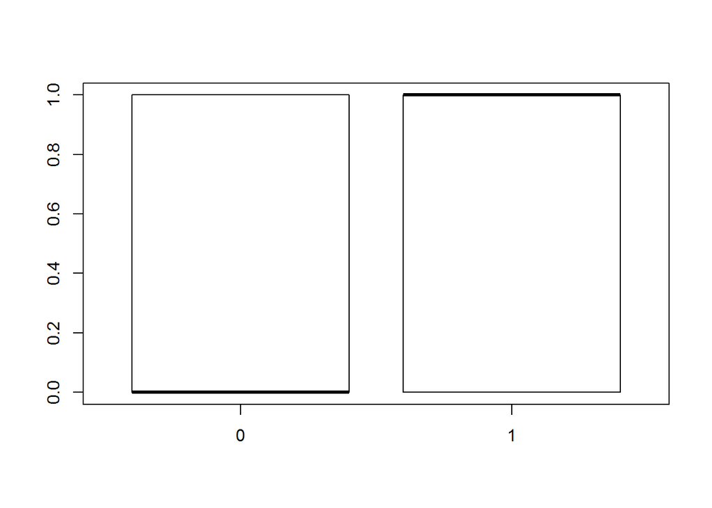

```r
# Plots
boxplot(q2data$first_stumble ~ q2data$handedness)
```

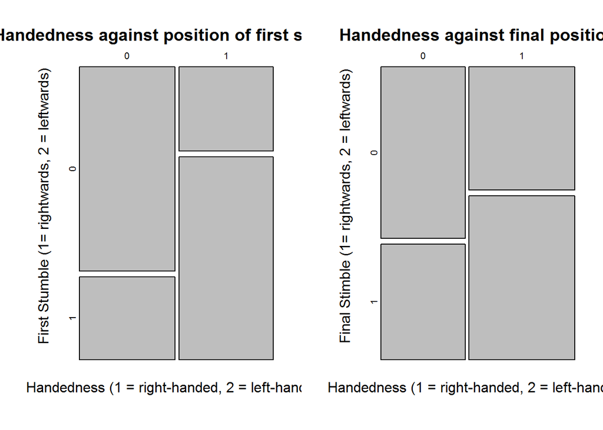

```r
par(mfrow = c(1,2),mar = c(4, 4, 2, 1),oma = c(0, 0, 1, 0))

mosaicplot(q2data$handedness ~ q2data$first_stumble, main = "Handedness against position of first stumble", ylab = "First Stumble (1= rightwards, 2 = leftwards)", xlab = "Handedness (1 = right-handed, 2 = left-handed)")

mosaicplot(q2data$final_position ~ q2data$handedness,main = "Handedness against final position",ylab = "Final Stimble (1= rightwards, 2 = leftwards)",xlab = "Handedness (1 = right-handed, 2 = left-handed)")
```

```r
wilcox.test(first_stumble ~ handedness, data = q2data, paired = FALSE)
```

```
##
##  Wilcoxon rank sum test with continuity correction
##
## data:  first_stumble by handedness
## W = 1661, p-value = 3.266e-07
## alternative hypothesis: true location shift is not equal to 0
```

```r
wilcox.test(final_position~handedness,data = q2data,paired = FALSE)
```

```
##
##  Wilcoxon rank sum test with continuity correction
##
## data:  final_position by handedness
## W = 2376, p-value = 0.04058
## alternative hypothesis: true location shift is not equal to 0
```

```r
par(mfrow = c(1,1),mar = c(4, 4, 2, 1),oma = c(0, 0, 1, 0))
```

## Outcome Analysis

Intoxication affects how a person is poitioned in their gait, there is a relationship between stumbling and handedness as well as stumbling and positioning.The pvalue was 0.04.So we can reject the null hypothesis.